# Exam2_Vashisht_Vinika

```r
#Loading required library
library(forecast)
library(fpp)
library(fpp2)
library(scales)
library(quantmod)
library(urca)
library(vars)
```

```r
library(tseries)
library(ggplot2)
library(dplyr)
library(TSA)
```

###Step 1: Plot the Data We first import the time series and plot it

```r
data= ts(scan("C:/Users/vashi/Desktop/Syllabus/Spring_2ndHalf/TimeSeries/Exam2.csv"), start=c(1961,1) ,frequency=4)
data
```

```
##           Qtr1      Qtr2      Qtr3      Qtr4
## 1961  0.710000  0.630000  0.850000  0.440000
## 1962  0.610000  0.690000  0.920000  0.550000
## 1963  0.720000  0.770000  0.920000  0.600000
## 1964  0.830000  0.800000  1.000000  0.770000
## 1965  0.920000  1.000000  1.240000  1.000000
## 1966  1.160000  1.300000  1.450000  1.250000
## 1967  1.260000  1.380000  1.860000  1.560000
## 1968  1.530000  1.590000  1.830000  1.860000
## 1969  1.530000  2.070000  2.340000  2.250000
## 1970  2.160000  2.430000  2.700000  2.250000
## 1971  2.790000  3.420000  3.690000  3.600000
## 1972  3.600000  4.320000  4.320000  4.050000
## 1973  4.860000  5.040000  5.040000  4.410000
## 1974  5.580000  5.850000  6.570000  5.310000
## 1975  6.030000  6.390000  6.930000  5.850000
## 1976  6.930000  7.740000  7.830000  6.120000
## 1977  7.740000  8.910000  8.280000  6.840000
## 1978  9.540000 10.260000  9.540000  8.729999
## 1979 11.880000 12.060000 12.150000  8.910000
## 1980 14.040000 12.960000 14.850000  9.990000
## 1981 16.200000 14.670000 16.020000 11.610000
```

```r
data %>%  ggtsdisplay(lag.max = 40)
```

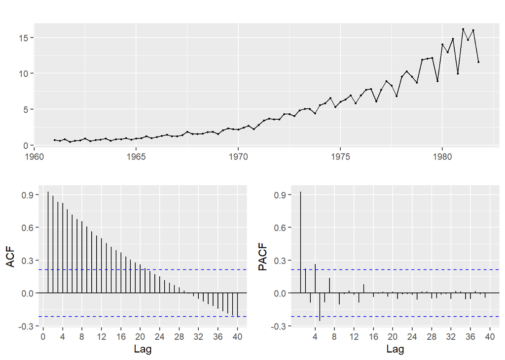

Next, we split the data in train and test

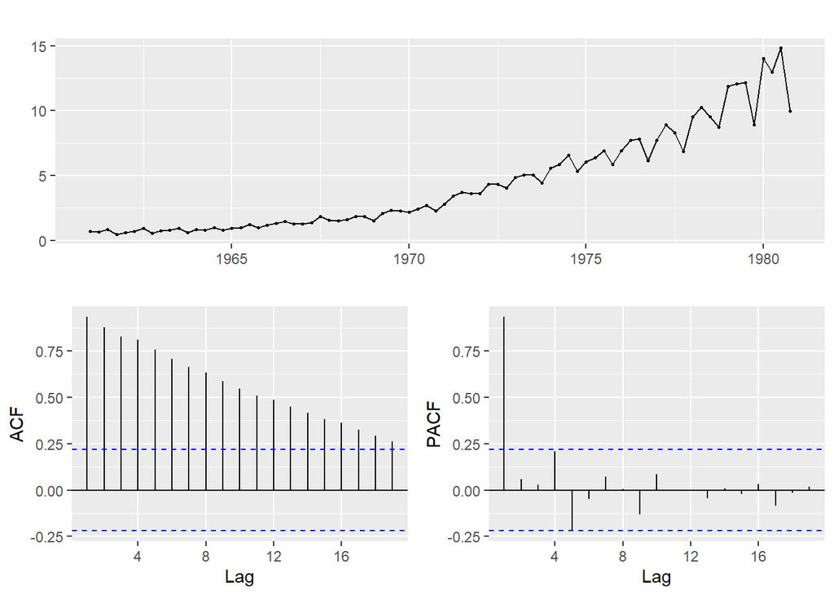

```r
data_train <- ts(data[1:80], start=c(1961,1) ,frequency=4)
data_train %>% ggtsdisplay()
```

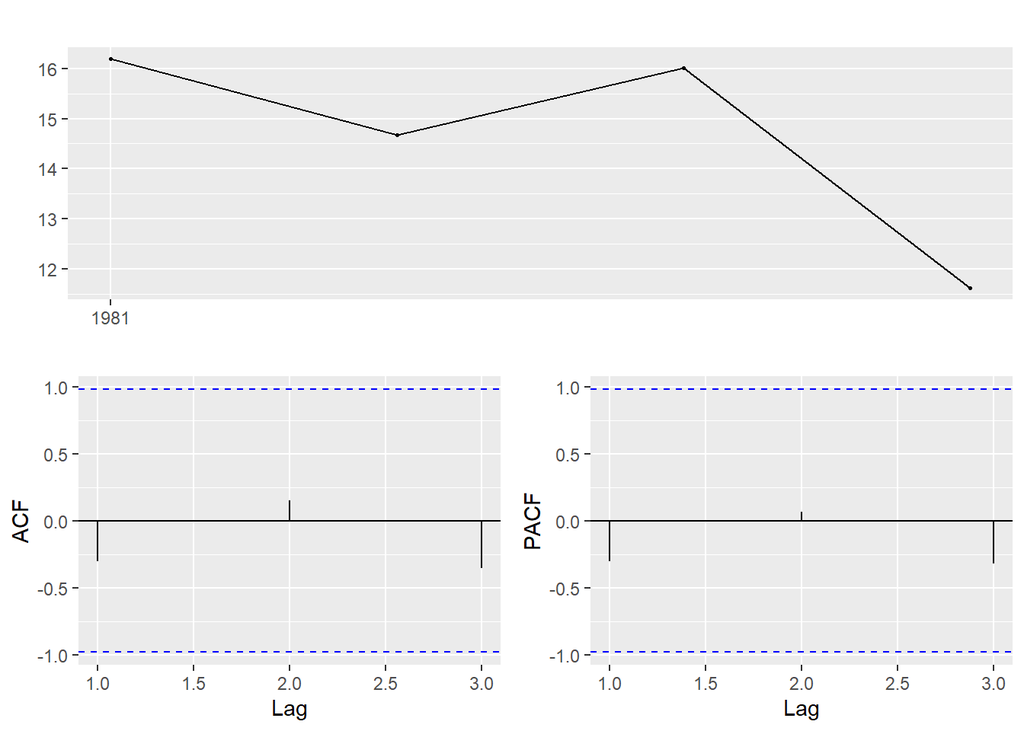

```r
data_test <- ts(data[81:84], start=c(1981,1) ,frequency=4)
data_test %>% ggtsdisplay(lag.max = 40)
```

It is a non stationary Time Series. Non constant mean, non constant variance. Trend, Seasonality both present.

###Step 2: Box-Cox transformation to stabilize the variance

```r
lamda <- BoxCox.lambda(data_train)
lamda
```

```
## [1] 0.1803894
```

Examine the sample ACF and sample PACF of log(x) and sqrt(x)

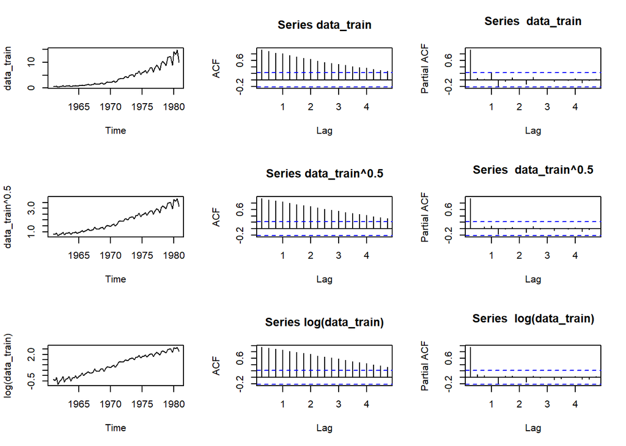

```r
par(mfrow=c(3,3))
plot(data_train)
acf(data_train)
pacf(data_train)
plot(data_train^0.5)
acf(data_train^0.5)
pacf(data_train^0.5)
plot(log(data_train))
acf(log(data_train))
pacf(log(data_train))
```

The best plot for non constant variance is obtained by taking log of time series. Hence, we continue with log transformation.

Taking log of original data

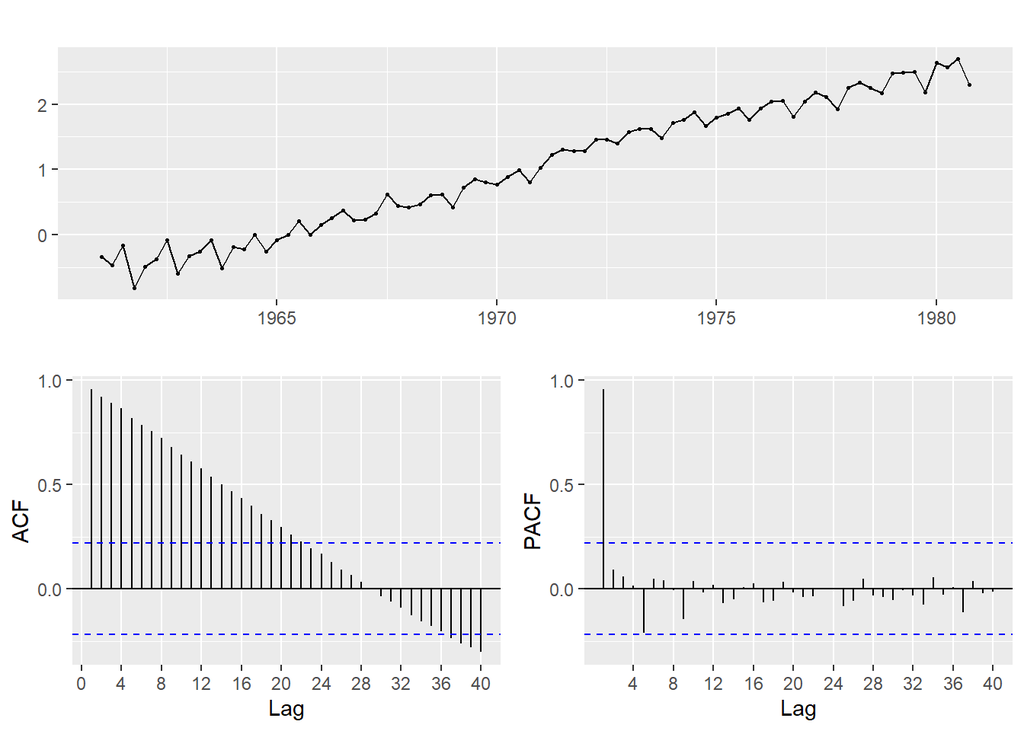

```r
data_train %>% log() %>% ggtsdisplay(lag.max=40)
```

```r
data_train %>% log() %>% adf.test()
```

```
##
##  Augmented Dickey-Fuller Test
##
## data:  .
## Dickey-Fuller = -1.3273, Lag order = 4, p-value = 0.8509
## alternative hypothesis: stationary
```

H0: Non stationary H1: Stationary As p-value > 0.05, we fail to reject the null hypothesis. Non stationary time series.

ACF= Slowly decreases. PACF= High spike at lag 1.

Hence, we take first order seasonal difference

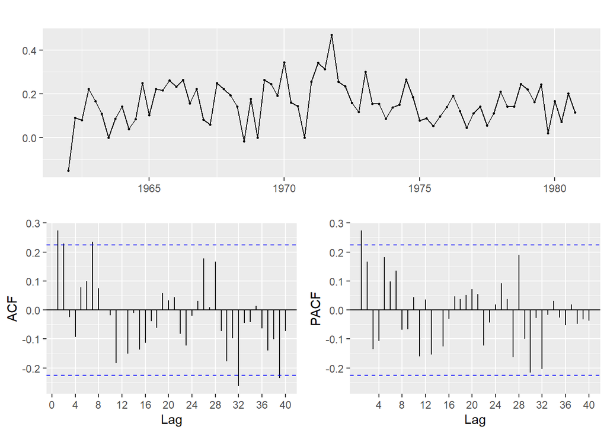

```r
data_train %>% log() %>% diff(lag=4) %>% ggtsdisplay(lag.max=40)
```

```r
data_train %>% log() %>% diff(lag=4) %>% adf.test()
```

```
##
##  Augmented Dickey-Fuller Test
##
## data:  .
## Dickey-Fuller = -3.0763, Lag order = 4, p-value = 0.1362
## alternative hypothesis: stationary
```

H0: Non stationary H1: Stationary As p-value > 0.05, we fail to reject the null hypothesis. Non stationary time series.

We take first order difference of the time series.

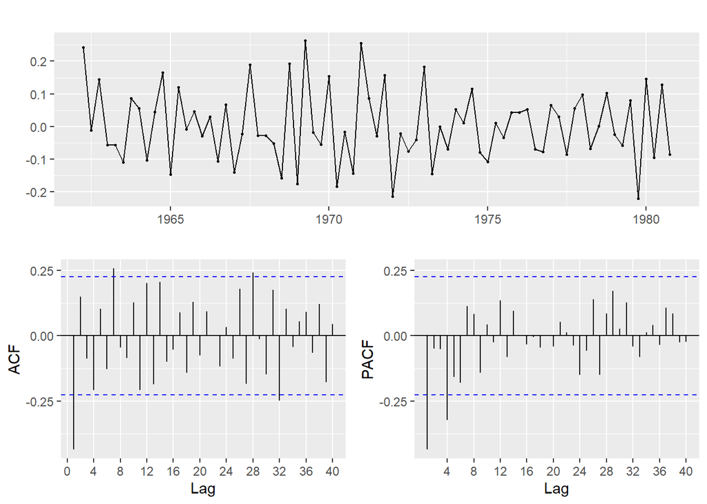

```r
data_train %>% log() %>% diff(lag=4) %>% diff() %>%  ggtsdisplay(lag.max=40)
```

```r
data_train %>% log() %>% diff(lag=4) %>% diff() %>%  adf.test()
```

```
##
##  Augmented Dickey-Fuller Test
##
## data:  .
## Dickey-Fuller = -6.6486, Lag order = 4, p-value = 0.01
## alternative hypothesis: stationary
```

H0: Non stationary H1: Stationary As p-value < 0.05, we reject the null hypothesis. Stationary time series.

Next, we try to run auto arima function to get a baseline model

###Step 4: Fitting a Model

1. ARIMA(0,1,1)(1,1,0)[4] using auto.arima

```r
fit0 <- data_train %>% auto.arima()
fit0
```

```
## Series: .
## ARIMA(0,1,1)(1,1,0)[4]
##
## Coefficients:
##           ma1    sar1
##       -0.7871  0.1950
## s.e.   0.0719  0.1299
##
## sigma^2 estimated as 0.1967:  log likelihood=-44.91
## AIC=95.81   AICc=96.15   BIC=102.76
```

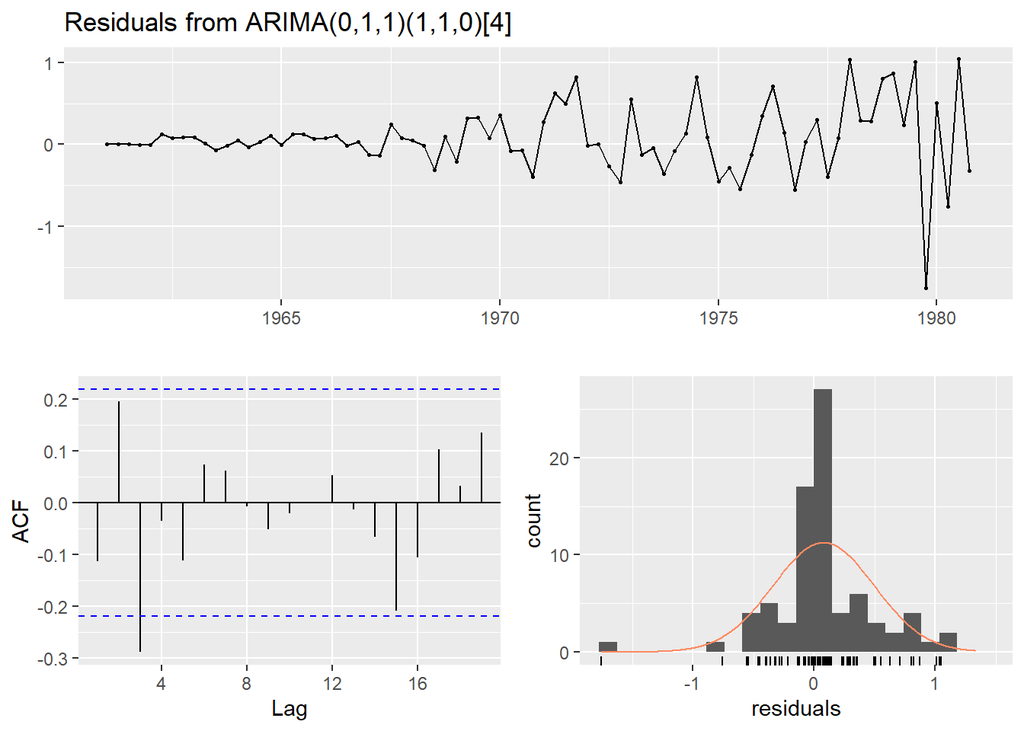

```
##
##  Ljung-Box test
##
## data:  Residuals from ARIMA(0,1,1)(1,1,0)[4]
## Q* = 13.45, df = 6, p-value = 0.03642
##
## Model df: 2.   Total lags used: 8
```

```r
checkresiduals(fit0)
```

As in the original plot of data_train obtained after taking log, first order difference and seasonal difference, for non seasonal, we see 2 spikes at 0 and 4 in PACF and one spike at lag 0 in ACF followed by exponential decay.This looks like MA(1) model

For seasonal component, we observe high spike at lag 4 in PACF and non significant spikes in ACF. This looks like AR(1) model.

2. ARIMA(0,1,1)(1,1,0)[4]

```r
fit1<-(data_train %>% Arima(order=c(0,1,1), seasonal=c(1,1,0), lambda= 0.18, include.constant = FALSE))
fit1
```

```
## Series: .
## ARIMA(0,1,1)(1,1,0)[4]
## Box Cox transformation: lambda= 0.18
##
## Coefficients:
##           ma1     sar1
##       -0.6955  -0.2832
## s.e.   0.0962   0.1158
##
## sigma^2 estimated as 0.01198:  log likelihood=59.94
## AIC=-113.87   AICc=-113.53   BIC=-106.92
```

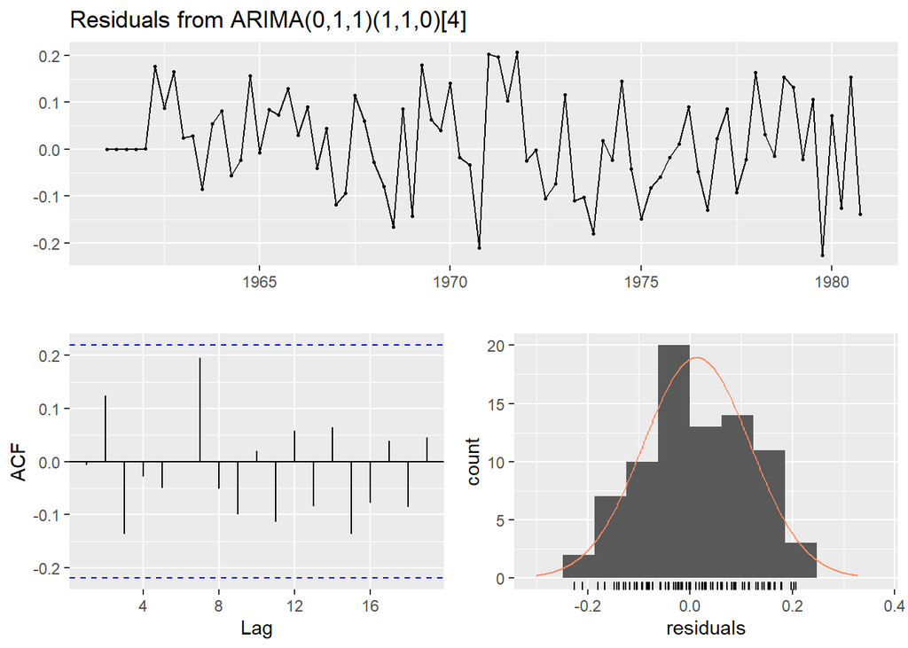

```
##
##  Ljung-Box test
##
## data:  Residuals from ARIMA(0,1,1)(1,1,0)[4]
## Q* = 6.8236, df = 6, p-value = 0.3375
##
## Model df: 2.   Total lags used: 8
```

```r
checkresiduals(fit1)
```

```r
coeftest(fit1)
```

```
##
## z test of coefficients:
##
##       Estimate Std. Error z value  Pr(>|z|)
## ma1  -0.695477   0.096155 -7.2329 4.728e-13 ***
## sar1 -0.283250   0.115810 -2.4458   0.01445 *
## ---
## Signif. codes:  0 '***' 0.001 '**' 0.01 '*' 0.05 '.' 0.1 ' ' 1
```

The residuals for the fit1 behave like white noise. Both the coeffiecients are also significant. But, we can check for other models also.

For non seasonal component, we can observe 2 spikes at 0 and 4 in PACF and can try AR(2) model. For seaonal component, we can go ahead with MA(1)

3. ARIMA(2,1,0)(0,1,1)[4]

```r
fit2<-(data_train %>% Arima(order=c(2,1,0), seasonal=c(0,1,1), lambda= 0.18,include.constant = FALSE))
fit2
```

```
## Series: .
## ARIMA(2,1,0)(0,1,1)[4]
## Box Cox transformation: lambda= 0.18
##
## Coefficients:
##           ar1      ar2     sma1
##       -0.5840  -0.1044  -0.3288
## s.e.   0.1187   0.1199   0.1122
##
## sigma^2 estimated as 0.0128:  log likelihood=58.13
## AIC=-108.26   AICc=-107.69   BIC=-98.99
```

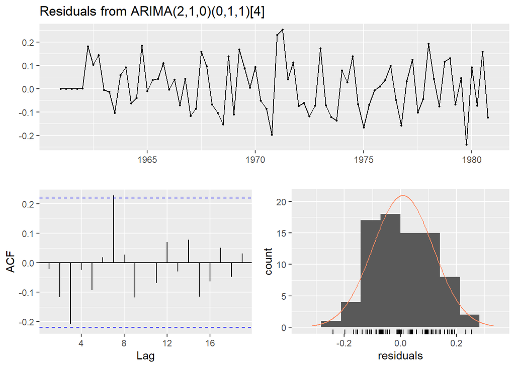

```
##
##  Ljung-Box test
##
## data:  Residuals from ARIMA(2,1,0)(0,1,1)[4]
## Q* = 10.421, df = 5, p-value = 0.06416
##
## Model df: 3.   Total lags used: 8
```

```r
checkresiduals(fit2)
```

3. ARIMA(2,1,1)(0,1,1)[4]

```r
fit3<-(data_train  %>% Arima(order=c(2,1,1), seasonal=c(0,1,1),lambda= 0.18, include.constant = FALSE))
fit3
```

```
## Series: .
## ARIMA(2,1,1)(0,1,1)[4]
## Box Cox transformation: lambda= 0.18
##
## Coefficients:
##          ar1     ar2      ma1     sma1
##       0.1582  0.2267  -0.8611  -0.2617
## s.e.  0.1974  0.1654   0.1530   0.1326
##
## sigma^2 estimated as 0.01196:  log likelihood=60.98
## AIC=-111.96   AICc=-111.09   BIC=-100.37
```

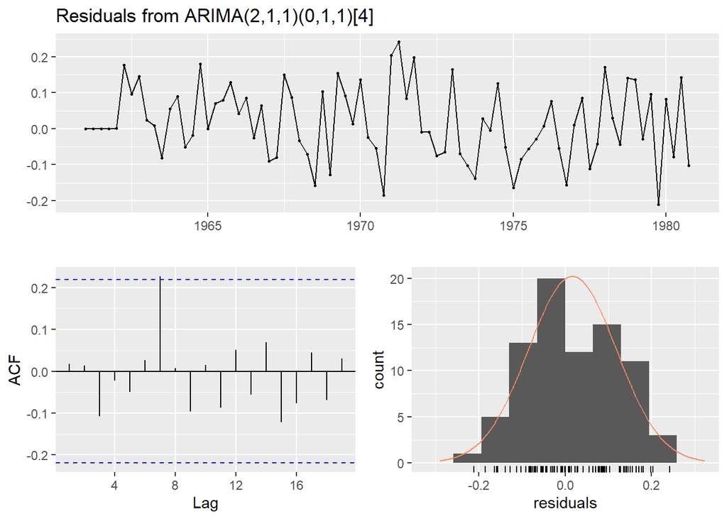

```
##
##  Ljung-Box test
##
## data:  Residuals from ARIMA(2,1,1)(0,1,1)[4]
## Q* = 5.9512, df = 4, p-value = 0.2028
##
## Model df: 4.   Total lags used: 8
```

```r
checkresiduals(fit3)
```

```r
(BIC(fit1))
```

```
## [1] -106.9196
```

```r
(BIC(fit2))
```

```
## [1] -98.99238
```

```r
(BIC(fit3))
```

```
## [1] -100.3722
```

As the BIC value of ARIMA(0,1,1)(1,1,0)[4] is the least as compared to other models. We can use this model for forecasting.

```r
#final model
fit4<-(data_train %>% Arima(order=c(0,1,1), seasonal=c(1,1,0), lambda= 0.18, include.constant = FALSE))
fit4
```

```
## Series: .
## ARIMA(0,1,1)(1,1,0)[4]
## Box Cox transformation: lambda= 0.18
##
## Coefficients:
##           ma1     sar1
##       -0.6955  -0.2832
## s.e.   0.0962   0.1158
##
## sigma^2 estimated as 0.01198:  log likelihood=59.94
## AIC=-113.87   AICc=-113.53   BIC=-106.92
```

```r
coeftest(fit4)
```

```
##
## z test of coefficients:
##
##       Estimate Std. Error z value  Pr(>|z|)
## ma1  -0.695477   0.096155 -7.2329 4.728e-13 ***
## sar1 -0.283250   0.115810 -2.4458   0.01445 *
## ---
## Signif. codes:  0 '***' 0.001 '**' 0.01 '*' 0.05 '.' 0.1 ' ' 1
```

Both ma1 and sar1 are significant as the p value is less than 0.05.

We can use lyung-Box test to check for autocorrelation in the lag

```r
Box.test(resid(fit4), lag=10, type= "Ljung-Box")
```

```
##
##  Box-Ljung test
##
## data:  resid(fit4)
## X-squared = 7.7826, df = 10, p-value = 0.6501
```

H0: No autocorrelation in the lags-> Data is like white noise H1: Autocorrelation in the lags

p-value> 0.05, no autocorrelation in the lags. We fail to reject the null hypothesis.

###Step 5: Overfitting

Using (p,q+1) and (p+1,q) we make 2 models and check for overfitting

```r
fit5<-(data_train %>% Arima(order=c(1,1,1),seasonal=c(1,1,1),lambda= 0.18, include.constant = FALSE))
coeftest(fit5)
```

```
##
## z test of coefficients:
##
##       Estimate Std. Error z value  Pr(>|z|)
## ar1  -0.037437   0.223549 -0.1675 0.8670012
## ma1  -0.662953   0.180732 -3.6682 0.0002443 ***
## sar1 -0.093979   0.389172 -0.2415 0.8091804
## sma1 -0.230564   0.375937 -0.6133 0.5396745
## ---
## Signif. codes:  0 '***' 0.001 '**' 0.01 '*' 0.05 '.' 0.1 ' ' 1
```

```r
fit6<-(data_train %>% Arima(order=c(0,1,2),seasonal=c(2,1,0),lambda= 0.18, include.constant = FALSE))
coeftest(fit6)
```

```
##
## z test of coefficients:
##
##       Estimate Std. Error z value  Pr(>|z|)
## ma1  -0.690394   0.114294 -6.0405 1.536e-09 ***
## ma2   0.015081   0.116548  0.1294   0.89705
## sar1 -0.324616   0.138949 -2.3362   0.01948 *
## sar2 -0.089713   0.127611 -0.7030   0.48205
## ---
## Signif. codes:  0 '***' 0.001 '**' 0.01 '*' 0.05 '.' 0.1 ' ' 1
```

In the first model, ma1 is the one coefficient which is significant. In second model, ma1 and sar1 are the only one significant.

###Step 6: Forecasting

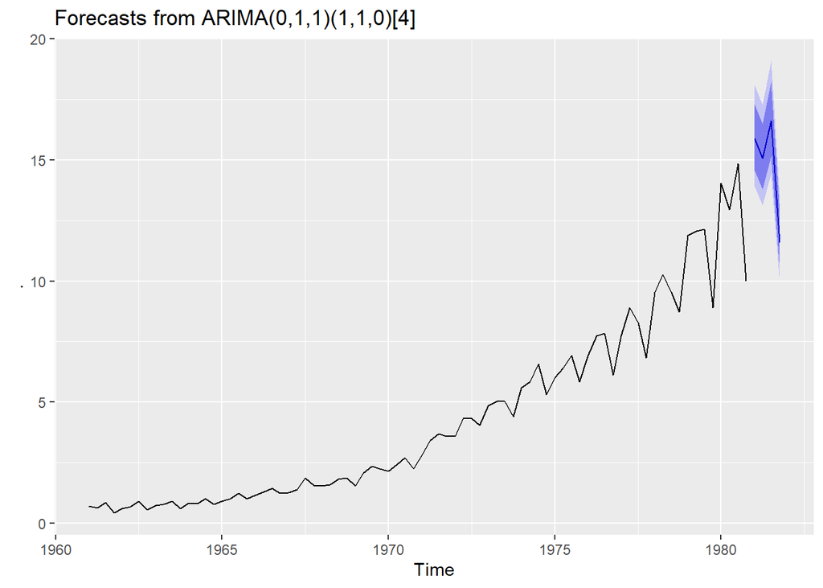

```r
fit4 %>% forecast(h=4) %>% autoplot()
```

```r
forecast(fit4,h=4)
```

```
##         Point Forecast    Lo 80    Hi 80     Lo 95    Hi 95
## 1981 Q1       15.88762 14.57921 17.29080 13.923208 18.07375
## 1981 Q2       15.08409 13.77587 16.49249 13.121951 17.28061
## 1981 Q3       16.62528 15.15080 18.21542 14.414785 19.10637
## 1981 Q4       11.58813 10.45395 12.82131  9.891447 13.51643
```

### Step 7: Checking for accuracy

```r
accuracy(fit4 %>% forecast(h=4), data_test)
```

```
##                       ME      RMSE       MAE        MPE     MAPE      MASE
## Training set  0.01676957 0.4304620 0.2858501  0.9765051 6.948150 0.4391471
## Test set     -0.17128189 0.3987137 0.3384032 -1.1210977 2.179392 0.5198836
##                    ACF1 Theil's U
## Training set -0.2865404        NA
## Test set     -0.1849115 0.1590747
```

The obtained Mean Absolute Percentage Error for test set is 2.17.

Accuracy-> 100 - 2.17 = 97.82

###Step 8: Equation of Model